# Playfair Balance of Trade Data

Michael Friendly

2025-02-04

Playfair’s (1801) [*Commercial and Political Atlas*](https://archive.org/details/PLAYFAIRWilliam1801TheCommercialandPoliticalAtlas) introduced the idea of line graphs for time series data. He used these to talk about the balance of trade England had with other countries. Let’s try to reproduce one of these, for trade with the East Indies, with `ggplot`.

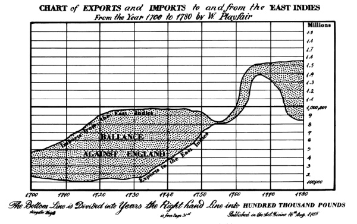

## Load the data & ggplot2

The data are contained in `GDAdata::EastIndiesTrade`. You may have to install the `GDAdata` package.

```r
library(ggplot2)
if (!require("GDAdata")) install.packages("GDAdata")
data(EastIndiesTrade,package="GDAdata")
head(EastIndiesTrade)
```

```
##   Year Exports Imports
## 1 1700     180     460
## 2 1701     170     480
## 3 1702     160     490
## 4 1703     150     500
## 5 1704     145     510
## 6 1705     140     525
```

## Plot two lines, for Exports & Imports

Playfair plotted Exports and Imports against Year with separate lines for each. The data are in a wide format, so to do this, I change the Y mapping for the second `geom_line()`.

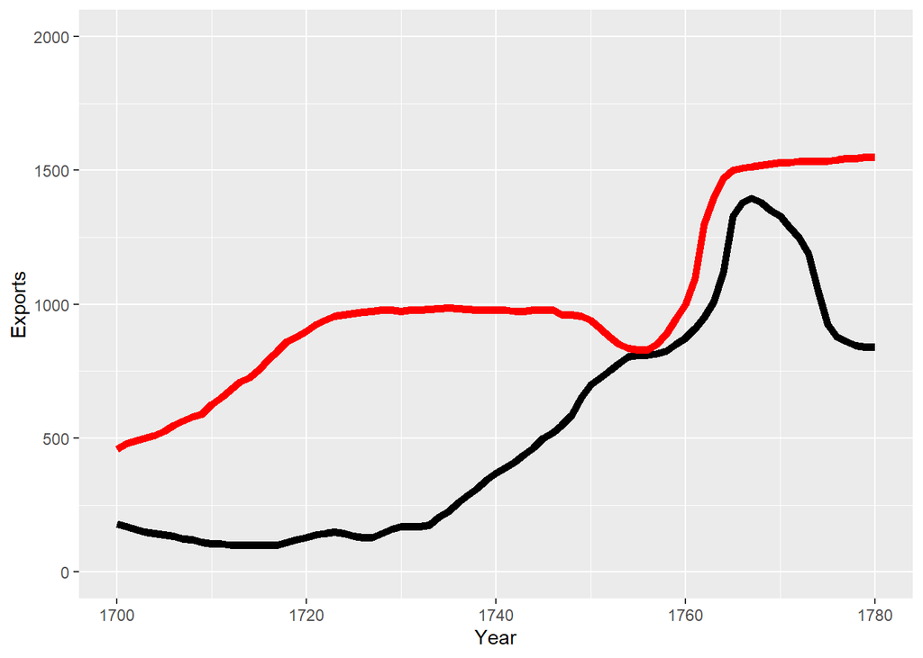

```r
c1 <- ggplot(EastIndiesTrade, aes(x=Year, y=Exports)) +
           ylim(0,2000) +
           geom_line(colour="black", linewidth=2) +
           geom_line(aes(x=Year, y=Imports), colour="red", linewidth=2)
print(c1)
```

## Fill the area between curves and change the Y label

`geom_ribbon()` is designed for this. It takes `ymin` and `ymax` aesthetics, here mapped to `Exports` and `Imports`. Note the use of `+` to add to an existing ggplot object.

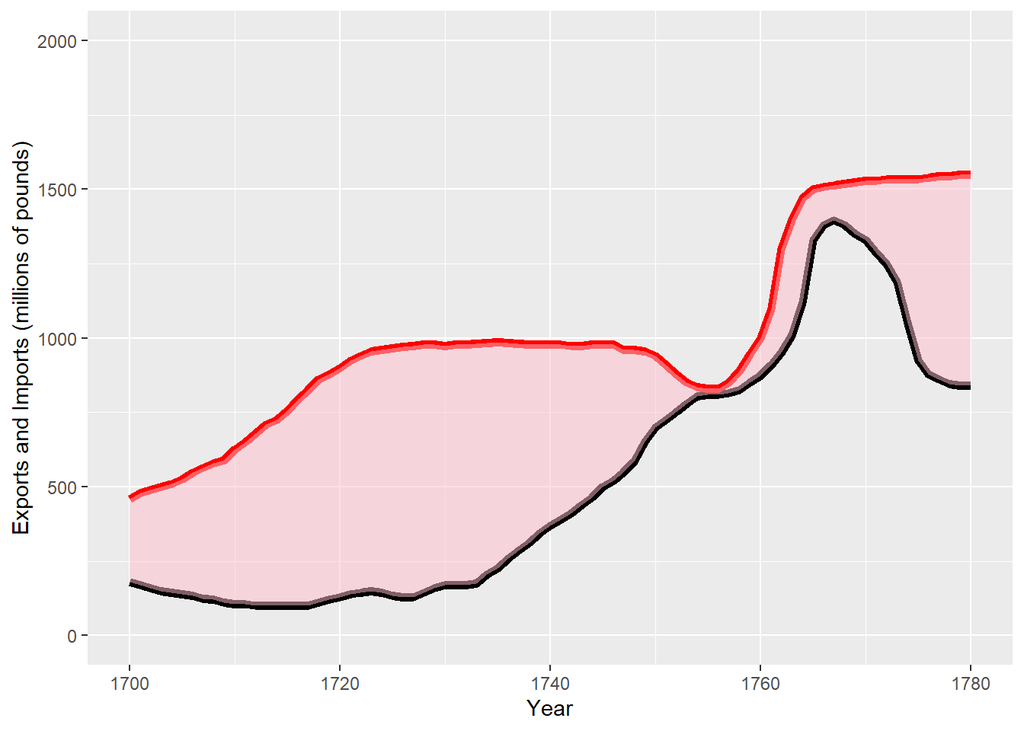

```r
c1 <- c1 +
         geom_ribbon(aes(ymin=Exports, ymax=Imports), fill="pink",alpha=0.5) +
         ylab("Exports and Imports (millions of pounds)")
print(c1)
```

## Add text annotations, change the theme

`annotate("text")` takes `x` and `y` coordinates in the units of the plot.

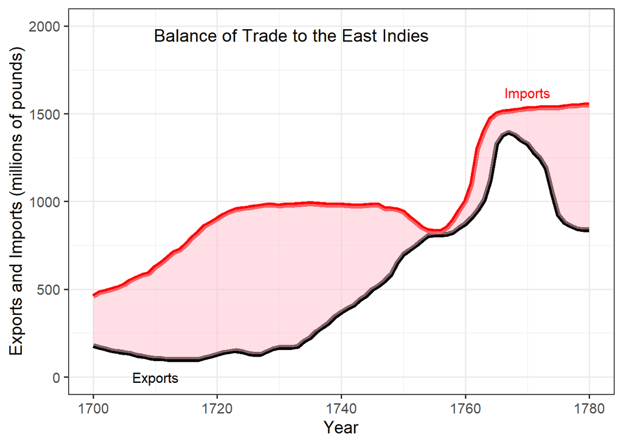

```r
c1 <- c1 +
         annotate("text", x = 1710, y = 0, label = "Exports", size=4) +
         annotate("text", x = 1770, y = 1620, label = "Imports", color="red", size=4) +
         annotate("text", x = 1732, y = 1950, label = "Balance of Trade to the East Indies", color="black", size=5) +
         theme_bw(base_size = 14)
print(c1)
```

## Plot trade deficit directly

In the mapping, simply use `y=Exports-Imports`

```r
c2 <- ggplot(EastIndiesTrade,
             aes(x=Year, y=Exports-Imports)) +
    geom_line(colour="red", size=2) +
    ylab("Balance = Exports - Imports") +
    geom_ribbon(aes(ymin=Exports-Imports, ymax=0), fill="pink",alpha=0.5) +
    annotate("text", x = 1710, y = -30, label = "Our Deficit", color="black", size=5) +
    theme_bw(base_size = 14)
```

## Combine the two plots into one

`ggplot` uses `grid` graphics under the hood, so plots can be combined using `gridExtra::grid.arrange()`.

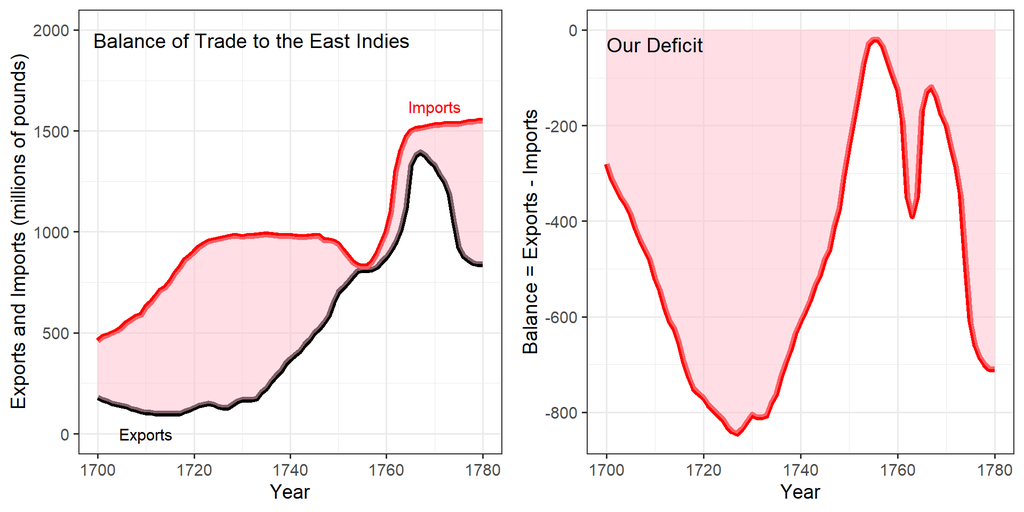

```r
library(gridExtra)
grid.arrange(c1, c2, nrow=1)
```

## Easier & more general with `patchwork`

The [`patchwork`](https://patchwork.data-imaginist.com/) package makes it “ridiculously simple to combine separate ggplots into the same graphic”

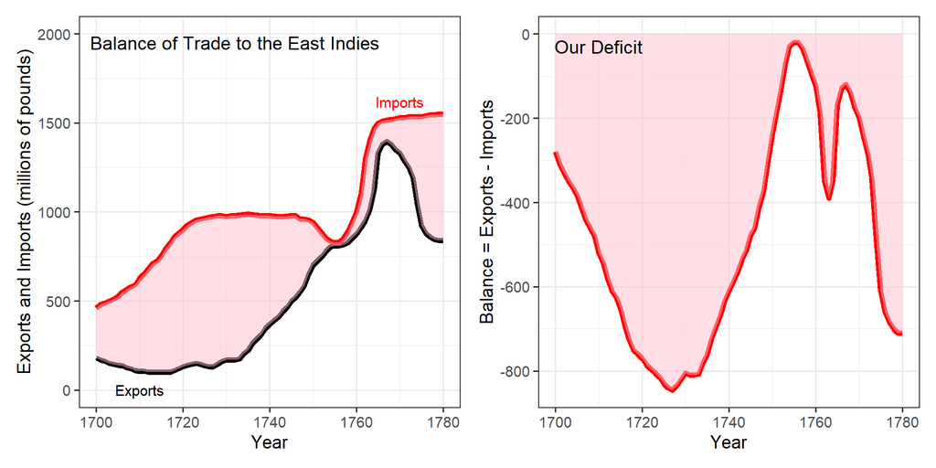

```r
library(patchwork)
c1 + c2
```

## Going further

I didn’t exactly reproduce Playfair’s chart. To do so more completely, I would:

- Find fonts that were closer to those he used for the plot title at the top, reading: “CHART of EXPORTS and IMPORTS …” and for the caption, reading “The Bottom Line is Divided …”. The [`showtext`](https://cran.rstudio.com/web/packages/showtext/vignettes/introduction.html) package makes them available in R.
- Where I simply labeled the curves “Imports” and “Exports”, I could use the [`geomtextpath`](https://allancameron.github.io/geomtextpath/) package to write longer labels following the curves.
- Move the internal title inside the two curves as Playfair did, but make it read “Balance Against England”
- Position the Y axis at the right, and try to mimic his markings.